# tsna Package Vignette

## Measures of sequence

In addition to measures of momentary structure, dynamic or longitudinal networks also give us the ability to explore sequences or patterns of events. The package `relevent` (Butts 2008) includes some statistical techniques for modeling relational event sequences, and the `tsna` package borrows the participation shift summary statistics from it.

### pShift

The function `pShiftCount` computes counts of dyadic turn-taking events using a typology outlined by Gibson (2003). Essentially, it looks at the sequence of events (rather than the exact timing) and counts up instances of various types of 'turn taking' speech acts. For example, two edges in sequence, 'i' talks to 'j', and then 'j' responds to 'i', is counted as one type of event, where 'i' talks to 'j' and then 'j' talks to 'k' would be another type of event. The set of events Gibson was interested in is certainly not an exhaustive list of potential sequences, but may still be an interesting approach for characterizing dynamic networks.

We can apply the the `pShiftCount` metric to the McFarland dataset of conversational speech acts in a classroom.

```r
data(McFarland_cls33_10_16_96)
pShiftCount(cls33_10_16_96)
```

```
    AB-BA AB-B0 AB-BY A0-X0 A0-XA A0-XY AB-X0 AB-XA AB-XB AB-XY A0-AY AB-A0
691   247     2    45     3     2     5     4     7     8   155     0     1
    AB-AY
691    29
```

By default, it gives us aback a vector with the counts of each type participation shifts. After consulting the docs (`?pShiftcount`) we see that there is a lot of call and response 'Turn Receiving' ('AB-BA') as well as quite a bit of 'Turn Usurping' ('AB-XY') events.

Since we don't really know what these numbers mean in absolute terms, it would be interesting to see if the counts change at various segments of time. So divide the time up into 5-minute intervals and compute counts for each

```r
sliceCounts<- lapply(seq(from = 0,to=45,by = 5),function(onset){
  pShiftCount(network.extract(cls33_10_16_96,onset,length = 5))
})
# convert to a matrix
sliceCounts<-do.call(rbind,sliceCounts)
sliceCounts
```

```
    AB-BA AB-B0 AB-BY A0-X0 A0-XA A0-XY AB-X0 AB-XA AB-XB AB-XY A0-AY AB-A0
67     10     1     1     1     0     1     0     3     0     2     0     0
134    21     0     2     1     1     3     3     0     0    11     0     1
46     23     0     4     0     0     0     0     0     1    13     0     0
47     23     0     4     0     0     0     0     3     0    15     0     0
103    31     0     5     1     0     1     1     0     1    23     0     0
71     36     0     6     0     0     0     0     1     2    24     0     0
74     37     0    11     0     0     0     0     0     0    22     0     0
76     38     0     7     0     0     0     0     0     1    26     0     0
73     25     1     5     0     1     0     0     0     3    15     0     0
    AB-AY
67     11
134     0
46      4
47      1
103     3
71      1
74      2
76      3
73      3
```

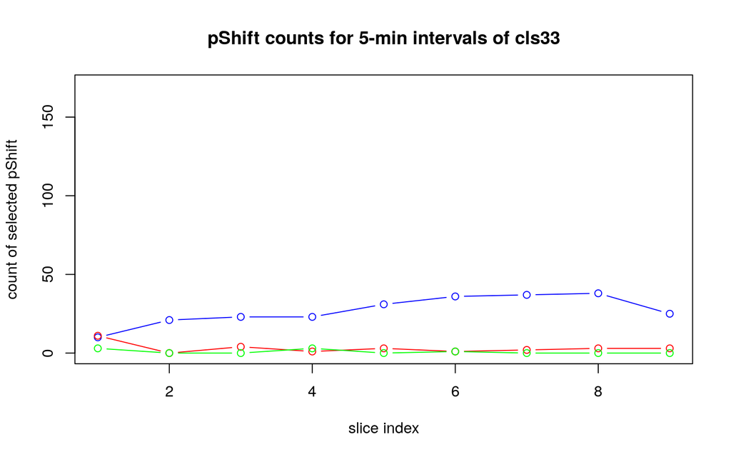

```r
# plot
plot(sliceCounts[,'AB-BA'],type='b',col='blue',ylim=c(0,170),
     main='pShift counts for 5-min intervals of cls33',
     ylab='count of selected pShift',xlab='slice index')
points(sliceCounts[,'AB-AY'],type='b',col='red')
points(sliceCounts[,'AB-XA'],type='b',col='green')
```

Perhaps it is interesting that the 'AB-BA' call-and-response starts out low and increases for most of the class, in contrast to the where the 'AB-AY' counts? But I think we'd need to go back and look at the narrative accounts for the classroom.

## Next steps

This package is far from complete. Most functions do not yet include ability to bin times necessary for working with certain types of continuous time networks. Include vertex activity functions, and correctly account for vertex activity in edge functions.

## Citation

```r
citation('tsna')
```

```
  Skye Bender-deMoll and Martina Morris (2020). tsna: Tools for
  Temporal Social Network Analysis. R package version 0.3.1.
  https://CRAN.R-project.org/package=tsna

A BibTeX entry for LaTeX users is

  @Manual{,
    title = {tsna: Tools for Temporal Social Network Analysis},
    author = {Skye Bender-deMoll and Martina Morris},
    year = {2020},
    note = {R package version 0.3.1},
    url = {https://CRAN.R-project.org/package=tsna},
  }
```

## Bibliography

Vincenzo Nicosia, John Tang, Cecilia Mascolo, Mirco Musolesi, Giovanni Russo, and Vito Latora (2013) Graph Metrics for Temporal Networks. https://arxiv.org/pdf/1306.0493v1.pdf

Skye Bender-deMoll (2014). networkDynamicData: dynamic network datasets. R package version 0.1.0. https://CRAN.R-project.org/package=networkDynamicData

B. Bui Xuan, Afonso Ferreira, Aubin Jarry. "Computing shortest, fastest, and foremost journeys in dynamic networks". RR-4589, 2002. https://hal.inria.fr/inria-00071996/document

Carter T. Butts, Ayn Leslie-Cook, Pavel N. Krivitsky and Skye Bender-deMoll (2015). networkDynamic: Dynamic Extensions for Network Objects. R package version 0.8. https://statnet.org

Carter T. Butts (2008). A Relational Event Framework for Social Action. Sociological Methodology, 38(1), 155-200.

Carter T. Butts (2014). sna: Tools for Social Network Analysis. R package version 2.3-2. https://CRAN.R-project.org/package=sna

Gibson, D.R. (2003) 'Participation Shifts: Order and Differentiation in Group Conversation' Social Forces 81 (4): 1335-1380 https://academic.oup.com/sf/article-abstract/81/4/1335/2234586

Handcock M, Hunter D, Butts C, Goodreau S, Krivitsky P and Morris M (2015). *ergm: Fit, Simulate and Diagnose Exponential-Family Models for Networks*. The Statnet Project (<URL: https://statnet.org>). R package version 3.4.0, <URL: https://CRAN.R-project.org/package=ergm>.

Moody, James. (2002) "The Importance of Relationship Timing for Diffusion." *Social Forces* 81:25-56

Moody, James (2008) "Static Representations of Dynamic Networks" Duke Population Research Institute On-line Working Paper Series. http://www.soc.duke.edu/~jmoody77/StatDyn_5.pdf